# BIOMI6300_Project1

Luna Eresta Jaya

2023-02-22

## Introduction

This is an R Markdown document that contains Project 1 of the BIOMI6300 course.

This project uses a simulated dataset based on an investigation of whether Vitamin B-12 improves a person’s cognitive ability. The simulation was based on summarized results from a randomized placebo-controlled trial in 7 general practices in South East England, UK. A total of 201 participants enrolled, which were divided into vitamin B-12 supplementation (referred to as the b12 group here) and placebo. Cognitive performance was measured after 30 days of supplementation by a verbal learning test.

In this R markdown file, I did: 1. Summarization of dataset 2. Plotting of datasets including bar graphs of number of observations per groups, as well as boxplots and histograms to compare the distributions of the two groups 3. T-test of dataset to determine significant difference in verbal learning tests between the two groups at a 95% confidence interval

Citation: Dangour, Alan D, et al. “Effects of Vitamin B-12 Supplementation on Neurologic and Cognitive Function in Older People: A Randomized Controlled TRIAL1,2.” The American Journal of Clinical Nutrition, vol. 102, no. 3, 2015, pp. 639–647., https://doi.org/10.3945/ajcn.115.110775. Link: https://academic.oup.com/ajcn/article/102/3/639/4564340

## Installing Packages

```r
# readxl package, to read excel files
# install.packages("readxl")
library(readxl)
# dplyr package, to organize and summarize tables
# install.packages("dplyr")
library(dplyr)
```

```r
# ggplot2 package, to create
# install.packages("ggplot2")
library(ggplot2)
```

## Load Vitamin B12 Study Dataset and Summarize it

```r
# Load the table
b12_study_dataset <- read_excel("vit_b12_study_dataset.xlsx")

# Look at the first few rows
head(b12_study_dataset)
```

```
## # A tibble: 6 × 2
##   group test_result
##   <chr>       <dbl>
## 1 b12          20.2
## 2 b12          22.4
## 3 b12          34.3
## 4 b12          24.4
## 5 b12          24.8
## 6 b12          35.4
```

```r
# Summarize the table
summary(b12_study_dataset)
```

```
##     group            test_result
##  Length:184         Min.   : 8.50
##  Class :character   1st Qu.:20.20
##  Mode  :character   Median :23.85
##                     Mean   :24.25
##                     3rd Qu.:28.23
##                     Max.   :46.20
```

```r
# Count the observations in each group
# Save counts into a new table called group_counts
group_counts <- b12_study_dataset %>%
  count(group, sort=TRUE)

# Group by experimental group and summarize mean, median, range
b12_study_dataset %>%
  group_by(group) %>%
  summarise(average = mean(test_result),
            median = median(test_result),
            range = max(test_result)-min(test_result))
```

```
## # A tibble: 2 × 4
##   group   average median range
##   <chr>     <dbl>  <dbl> <dbl>
## 1 b12        24.3   24.3  29.9
## 2 placebo    24.2   23.2  35.3
```

## Creating Plots from My Data

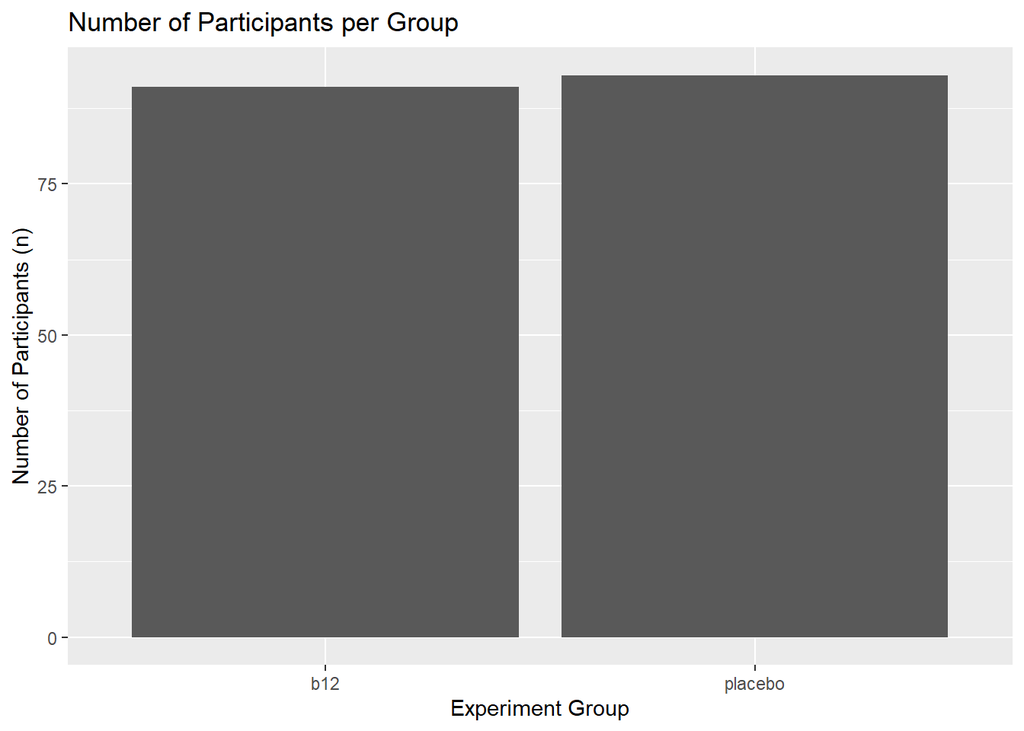

```r
# Creating a figure with the number of participants per group
figure_1_counts <- ggplot(group_counts, aes(x=group, y=n)) +
  geom_bar(stat="identity") +
  # labels
  labs(y="Number of Participants (n)",
       x="Experiment Group",
       title="Number of Participants per Group")
figure_1_counts
```

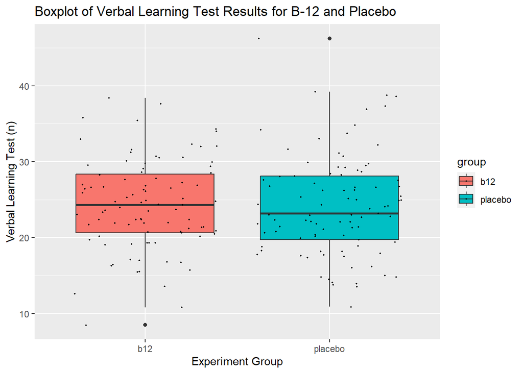

```r
ggsave("figure_1_counts.jpeg")
# Creating a boxplot to compare the median and ranges of the two groups
figure_2_boxplot <- ggplot(b12_study_dataset, aes(x=group, y=test_result, fill=group)) +
  geom_boxplot() +
  # dots on top of boxplot
  geom_jitter(size=0.4, alpha=0.9)+
  # labels
  labs(y="Verbal Learning Test (n)",
       x="Experiment Group",
       title="Boxplot of Verbal Learning Test Results for B-12 and Placebo")
figure_2_boxplot
```

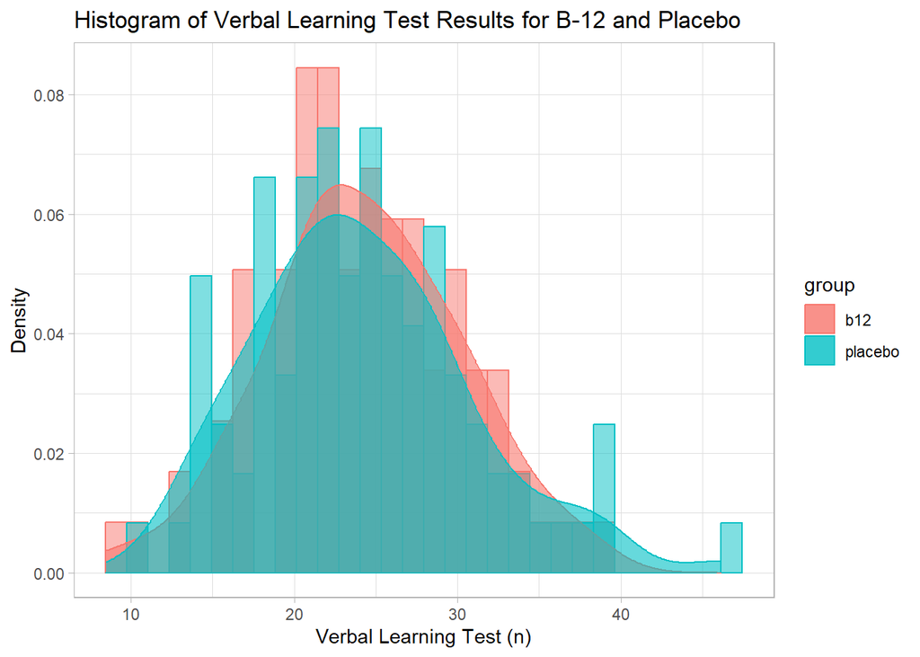

```r
ggsave("figure_2_boxplot.jpeg")
# Creating a histogram to compare the distributions of the two groups
figure_3_histogram <- ggplot(data=b12_study_dataset, aes(x=test_result, color=group, fill=group)) +
  # add histogram with density as y axis
  geom_histogram(aes(y=..density..), alpha=0.5, position="identity") +
  # add a smooth density plot
  geom_density(alpha=0.6) +
  # labels
  labs(y="Density",
       x="Verbal Learning Test (n)",
       title="Histogram of Verbal Learning Test Results for B-12 and Placebo") +
  theme_light()
figure_3_histogram
```

```r
ggsave("figure_3_histogram.jpeg")
```

## Doing a statistical test

Conduct a t-test to test whether there is significance difference between the verbal learning tests between the B12 and placebo groups.

```r
t.test(test_result ~ group, data = b12_study_dataset,
 alternative="greater",
 conf.level=0.95)
```

```
##
##  Welch Two Sample t-test
##
## data:  test_result by group
## t = 0.13179, df = 180.52, p-value = 0.4476
## alternative hypothesis: true difference in means between group b12 and group placebo is greater than 0
## 95 percent confidence interval:
##  -1.418805       Inf
## sample estimates:
##     mean in group b12 mean in group placebo
##              24.31429              24.19140
```

As p-value>0.05, there does not seem to be a significance difference between the two.